# Predict Property

Quang Trung

March 31, 2019

# REAL ESTATE

this is a report, prediction’Property. Dataset: kaggle.

### Problem : Using several of feature to predict sale price

### Description of features

MSSubClass: Identifies the type of dwelling involved in the sale.

```
    20  1-STORY 1946 & NEWER ALL STYLES
    30  1-STORY 1945 & OLDER
    40  1-STORY W/FINISHED ATTIC ALL AGES
    45  1-1/2 STORY - UNFINISHED ALL AGES
    50  1-1/2 STORY FINISHED ALL AGES
    60  2-STORY 1946 & NEWER
    70  2-STORY 1945 & OLDER
    75  2-1/2 STORY ALL AGES
    80  SPLIT OR MULTI-LEVEL
    85  SPLIT FOYER
    90  DUPLEX - ALL STYLES AND AGES
   120  1-STORY PUD (Planned Unit Development) - 1946 & NEWER
   150  1-1/2 STORY PUD - ALL AGES
   160  2-STORY PUD - 1946 & NEWER
   180  PUD - MULTILEVEL - INCL SPLIT LEV/FOYER
   190  2 FAMILY CONVERSION - ALL STYLES AND AGES
```

LotFrontage: Linear feet of street connected to property

LotArea: Lot size in square feet

OverallQual: Rates the overall material and finish of the house

```
   10   Very Excellent
   9    Excellent
   8    Very Good
   7    Good
   6    Above Average
   5    Average
   4    Below Average
   3    Fair
   2    Poor
   1    Very Poor
```

OverallCond: Rates the overall condition of the house

```
   10   Very Excellent
   9    Excellent
   8    Very Good
   7    Good
   6    Above Average
   5    Average
   4    Below Average
   3    Fair
   2    Poor
   1    Very Poor
```

YearBuilt: Original construction date

YearRemodAdd: Remodel date (same as construction date if no remodeling or additions)

MasVnrArea: Masonry veneer area in square feet

BsmtFinType1: Rating of basement finished area

```
   GLQ  Good Living Quarters
   ALQ  Average Living Quarters
   BLQ  Below Average Living Quarters
   Rec  Average Rec Room
   LwQ  Low Quality
   Unf  Unfinshed
   NA   No Basement
```

BsmtFinSF1: Type 1 finished square feet

BsmtFinType2: Rating of basement finished area (if multiple types)

```
   GLQ  Good Living Quarters
   ALQ  Average Living Quarters
   BLQ  Below Average Living Quarters
   Rec  Average Rec Room
   LwQ  Low Quality
   Unf  Unfinshed
   NA   No Basement
```

BsmtFinSF2: Type 2 finished square feet

BsmtUnfSF: Unfinished square feet of basement area

TotalBsmtSF: Total square feet of basement area

1stFlrSF: First Floor square feet

2ndFlrSF: Second floor square feet

LowQualFinSF: Low quality finished square feet (all floors)

GrLivArea: Above grade (ground) living area square feet

BsmtFullBath: Basement full bathrooms

BsmtHalfBath: Basement half bathrooms

FullBath: Full bathrooms above grade

HalfBath: Half baths above grade

Bedroom: Bedrooms above grade (does NOT include basement bedrooms)

Kitchen: Kitchens above grade

TotRmsAbvGrd: Total rooms above grade (does not include bathrooms)

GarageYrBlt: Year garage was built

GarageCars: Size of garage in car capacity

GarageArea: Size of garage in square feet

WoodDeckSF: Wood deck area in square feet

OpenPorchSF: Open porch area in square feet

EnclosedPorch: Enclosed porch area in square feet

3SsnPorch: Three season porch area in square feet

ScreenPorch: Screen porch area in square feet

PoolArea: Pool area in square feet

DMoSold: Month Sold (MM)

YrSold: Year Sold (YYYY)

## Descriptive statistics

#### OutCome variable :SalePrice

```
##    Min. 1st Qu.  Median    Mean 3rd Qu.    Max.
##   34900  129975  163000  180921  214000  755000
```

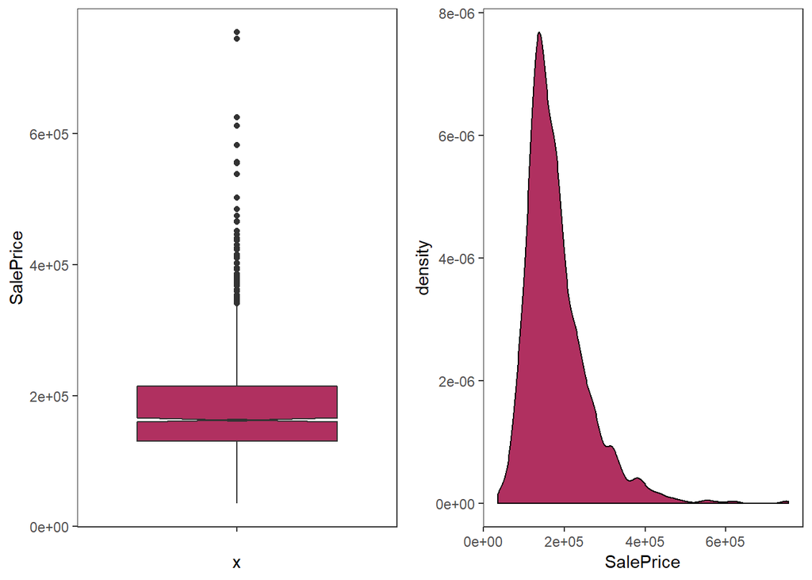

[output not shown]

### Detail Feature

#### 1:MSSubClass

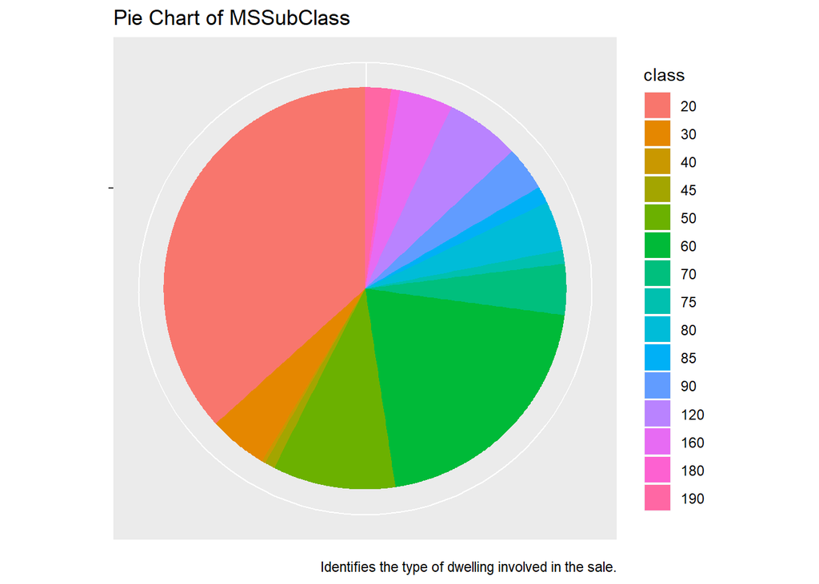

```
##  20  30  40  45  50  60  70  75  80  85  90 120 160 180 190
## 536  69   4  12 144 299  60  16  58  20  52  87  63  10  30
```

So we see : type 20 (536 obs), type 60 (299 obs) and type 50 (144 obs) are favor type.

#### 2:LotFrontage

Linear feet of street connected to property

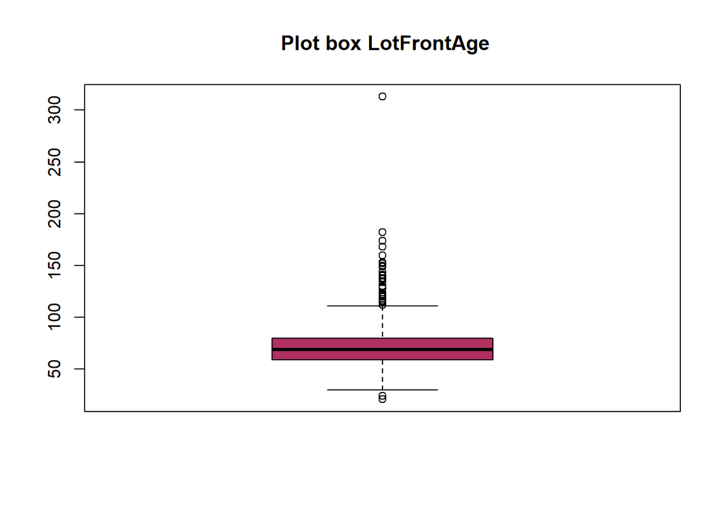

```
##    Min. 1st Qu.  Median    Mean 3rd Qu.    Max.    NA's
##   21.00   59.00   69.00   70.05   80.00  313.00     259
```

```
## Call:corr.test(x = vars)
## Correlation matrix
##             LotFrontage SalePrice
## LotFrontage        1.00      0.35
## SalePrice          0.35      1.00
## Sample Size
##             LotFrontage SalePrice
## LotFrontage        1201      1201
## SalePrice          1201      1460
## Probability values (Entries above the diagonal are adjusted for multiple tests.)
##             LotFrontage SalePrice
## LotFrontage           0         0
## SalePrice             0         0
##
##  To see confidence intervals of the correlations, print with the short=FALSE option
```

[output not shown]

#### 3:LotArea

Lot size in square feet

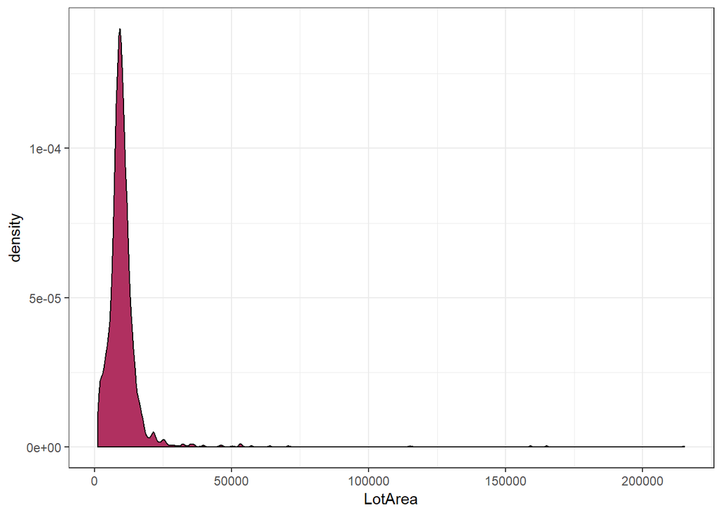

```
##    Min. 1st Qu.  Median    Mean 3rd Qu.    Max.
##    1300    7554    9478   10517   11602  215245
```

```
## Call:corr.test(x = cbind(LotArea, SalePrice))
## Correlation matrix
##           LotArea SalePrice
## LotArea      1.00      0.26
## SalePrice    0.26      1.00
## Sample Size
## [1] 1460
## Probability values (Entries above the diagonal are adjusted for multiple tests.)
##           LotArea SalePrice
## LotArea         0         0
## SalePrice       0         0
##
##  To see confidence intervals of the correlations, print with the short=FALSE option
```

#### 5-6 : OverallQual ,OverallCond.

OverallQual: Rates the overall material and finish of the house .

OverallCond: Rates the overall condition of the house

```
       10   Very Excellent
       9    Excellent
       8    Very Good
       7    Good
       6    Above Average
       5    Average
       4    Below Average
       3    Fair
       2    Poor
       1    Very Poor
```

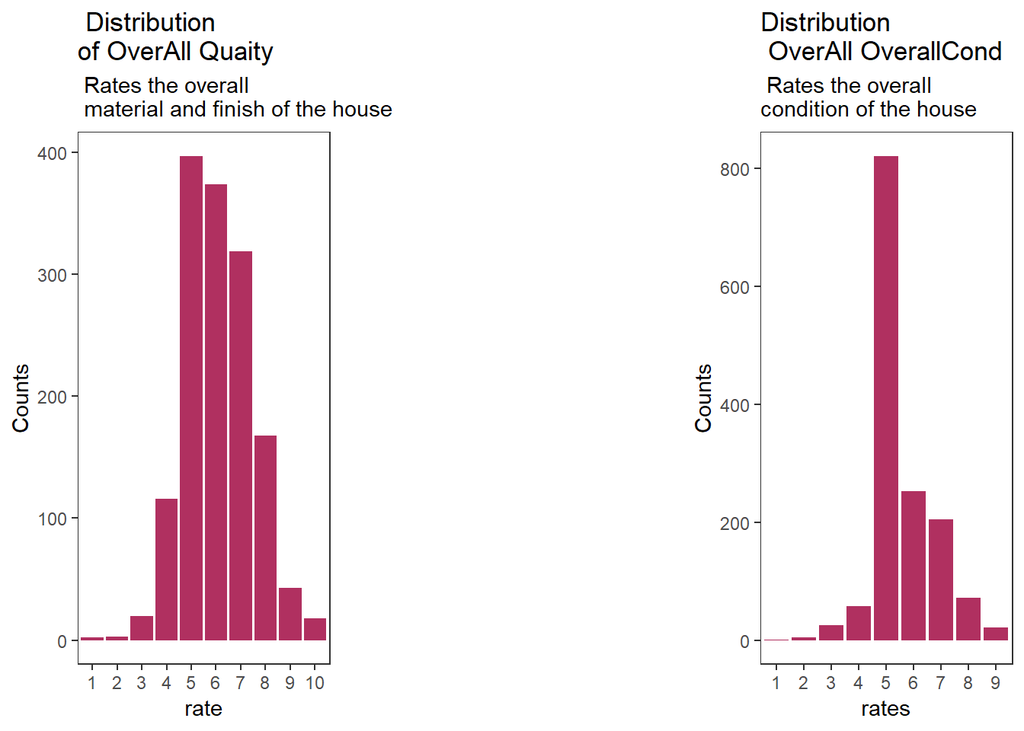

From plot. We see rates 5 6 7 the mostly

#### 7-8 : YearBuilt and YearRemodAdd

YearBuilt: Original construction date

YearRemodAdd: Remodel date (same as construction date if no remodeling or additions)

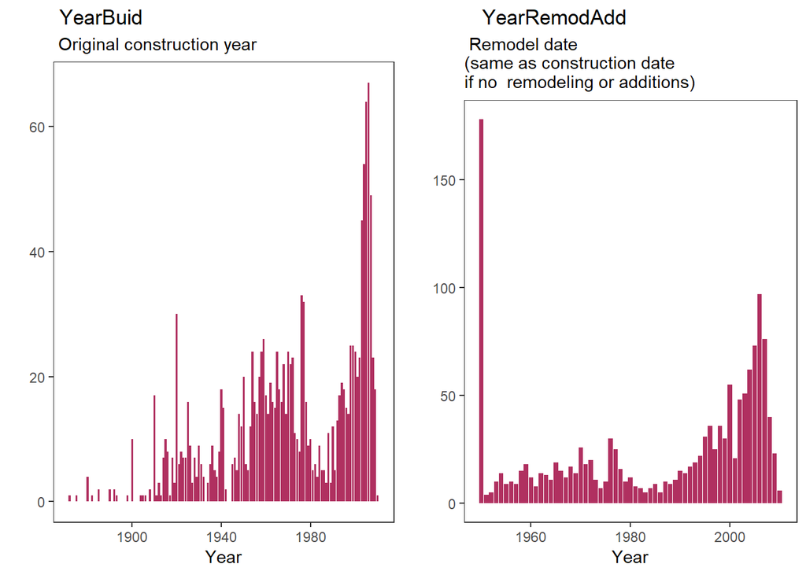

```
## [1] "YearBuilt summary"
```

```
##    Min. 1st Qu.  Median    Mean 3rd Qu.    Max.
##    1872    1954    1973    1971    2000    2010
```

```
## [1] "YearRemodAdd summary"
```

```
##    Min. 1st Qu.  Median    Mean 3rd Qu.    Max.
##    1950    1967    1994    1985    2004    2010
```

#### 9 - 10 :YrSold and MoSold

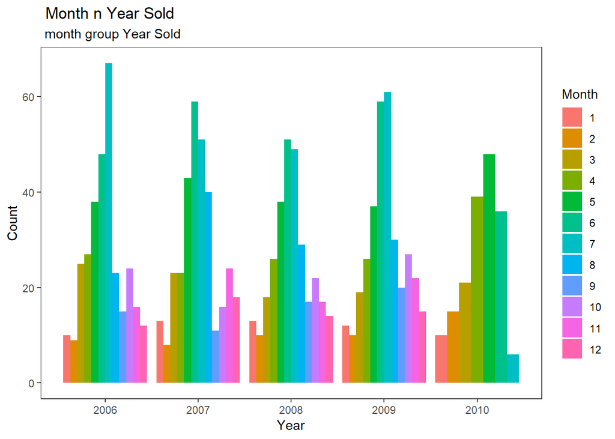

Insight : Summer is the best time for sale

#### 11 :GarageYrBlt

GarageYrBlt Year garage was built

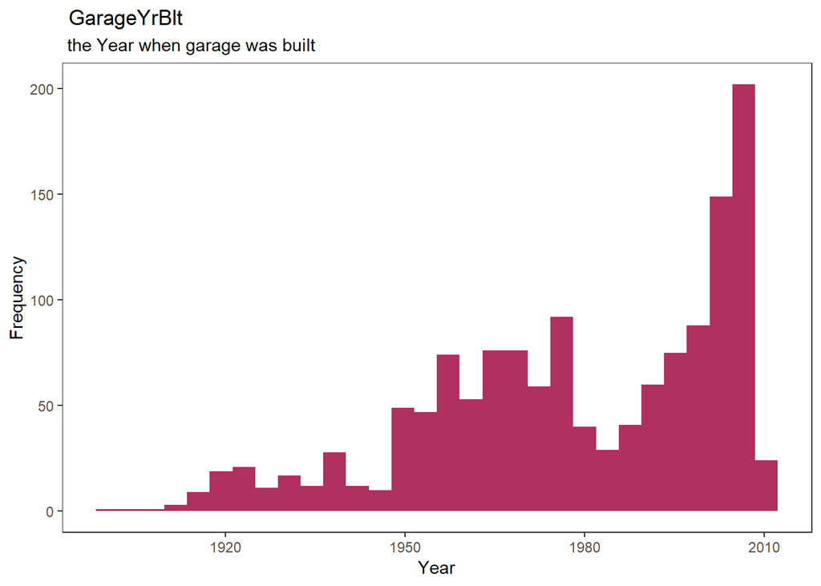

```
##    Min. 1st Qu.  Median    Mean 3rd Qu.    Max.    NA's
##    1900    1961    1980    1979    2002    2010      81
```

#### 12 -13 :GarageCars and GarageArea

GarageCars: Size of garage in car capacity

GarageArea: Size of garage in square feet

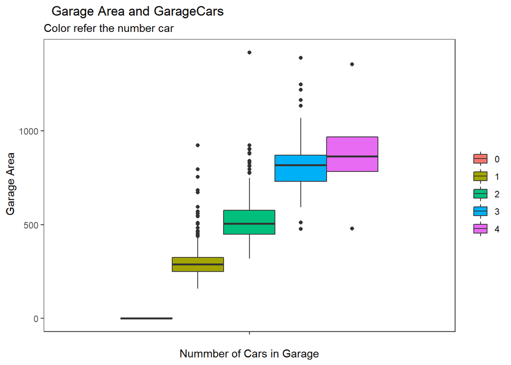

```
## [1] "GarageArea"
```

```
##    Min. 1st Qu.  Median    Mean 3rd Qu.    Max.
##     0.0   334.5   480.0   473.0   576.0  1418.0
```

```
## [1] "GarageCars"
```

```
##   0   1   2   3   4
##  81 369 824 181   5
```

#### 14-22:WoodDeckSF , OpenPorchSF , EnclosedPorch , ThreeSsnPorch ,ScreenPorch

#### PoolArea,MasVnrArea,MasVnrArea , 1stFlrSF ,2ndFlrSF,

WoodDeckSF: Wood deck area in square feet

OpenPorchSF: Open porch area in square feet

EnclosedPorch: Enclosed porch area in square feet

ThreeSsnPorch: Three season porch area in square feet

ScreenPorch: Screen porch area in square feet

PoolArea: Pool area in square feet

MasVnrArea: Masonry veneer area in square feet

1stFlrSF: First Floor square feet

2ndFlrSF: Second floor square feet

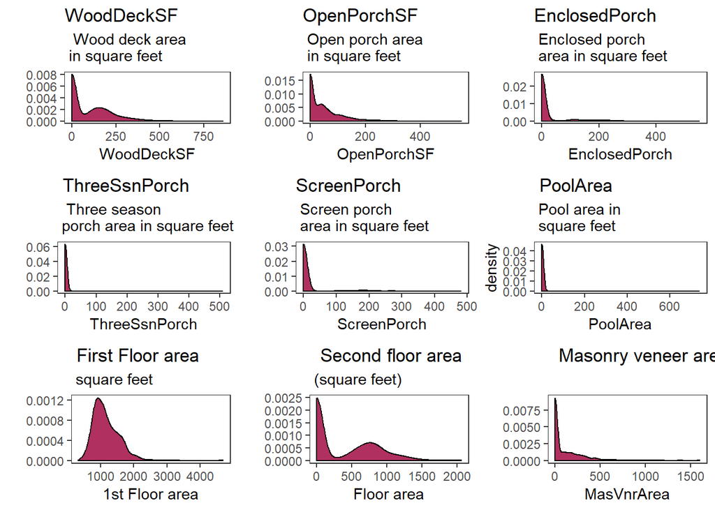

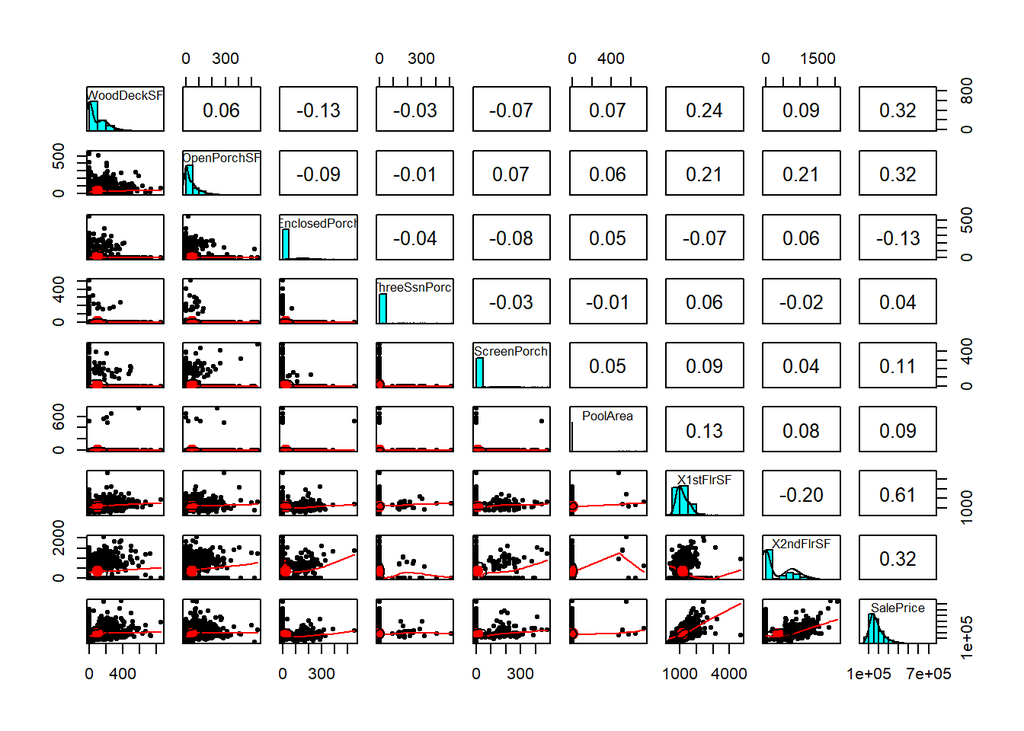

WoodDeckSF,OpenPorchSF,EnclosedPorch,ThreeSsnPorch,ScreenPorch,PoolArea,X1stFlrSF,X2ndFlrSF,

```
   WoodDeckSF      OpenPorchSF     EnclosedPorch    ThreeSsnPorch     ScreenPorch        PoolArea
 Min.   :  0.00   Min.   :  0.00   Min.   :  0.00   Min.   :  0.00   Min.   :  0.00   Min.   :  0.000
 1st Qu.:  0.00   1st Qu.:  0.00   1st Qu.:  0.00   1st Qu.:  0.00   1st Qu.:  0.00   1st Qu.:  0.000
 Median :  0.00   Median : 25.00   Median :  0.00   Median :  0.00   Median :  0.00   Median :  0.000
 Mean   : 94.24   Mean   : 46.66   Mean   : 21.95   Mean   :  3.41   Mean   : 15.06   Mean   :  2.759
 3rd Qu.:168.00   3rd Qu.: 68.00   3rd Qu.:  0.00   3rd Qu.:  0.00   3rd Qu.:  0.00   3rd Qu.:  0.000
 Max.   :857.00   Max.   :547.00   Max.   :552.00   Max.   :508.00   Max.   :480.00   Max.   :738.000


   X2ndFlrSF       X1stFlrSF
 Min.   :   0     Min.   : 334
 1st Qu.:   0     1st Qu.: 882
 Median :   0     Median :1087
 Mean   : 347     Mean   :1163
 3rd Qu.: 728     3rd Qu.:1391
 Max.   :2065     Max.   :4692
```

The matix above is correlation matrix .

1stFlrSF has the biggest value (0.61). x2ndFlrSF and Wooddesktop (0.32). they effect Sale price

#### 23-24-25-26:BsmtFinSF1 , BsmtFinType1, BsmtFinSF2 and BsmtFinType2

BsmtFinSF1: Type 1 finished square feet

BsmtFinType1: Rating of basement finished area

BsmtFinSF2: Type 2 finished square feet ##

BsmtFinType2: Rating of basement finished area (if multiple types)

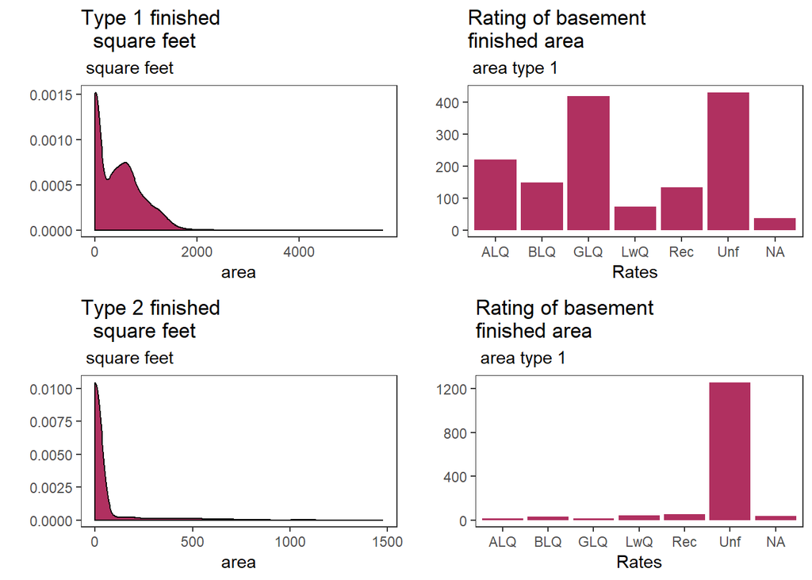

```
## [1] "Correlation matrix"
```

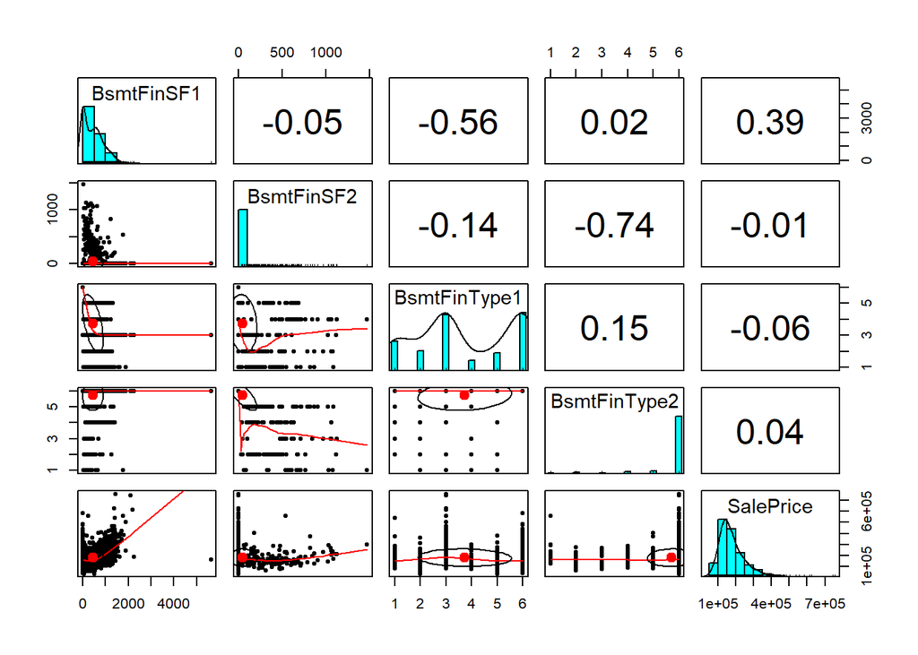

```
    BsmtFinSF1       BsmtFinSF2            BsmtFinType1        BsmtFinType2
  Min.   :   0.0   Min.   :   0.00         ALQ :220             ALQ :  19
  1st Qu.:   0.0   1st Qu.:   0.00         BLQ :148             BLQ :  33
  Median : 383.5   Median :   0.00         GLQ :418             GLQ :  14
  Mean   : 443.6   Mean   :  46.55         LwQ : 74             LwQ :  46
  3rd Qu.: 712.2   3rd Qu.:   0.00         Rec :133             Rec :  54
   Max.   :5644.0   Max.   :1474.00        Unf :430             Unf :1256
                                           NA's: 37             NA's:  38
```

#### LowQualFinSF ,GrLivArea,BsmtFullBath,BsmtHalfBath,BsmtFullBath,HalfBath

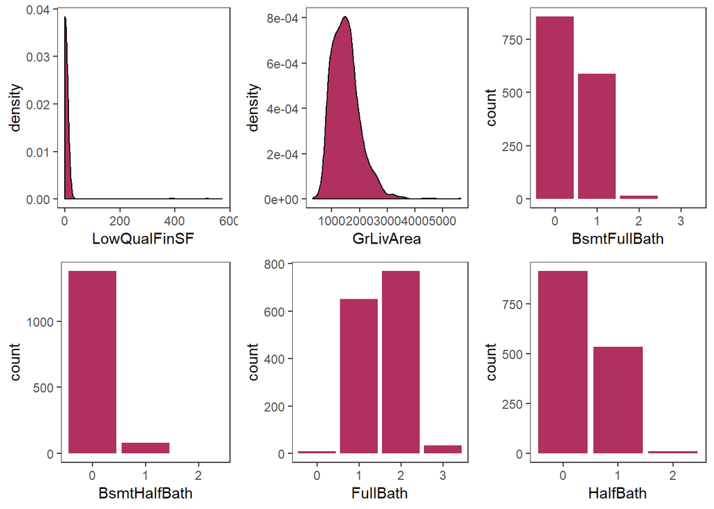

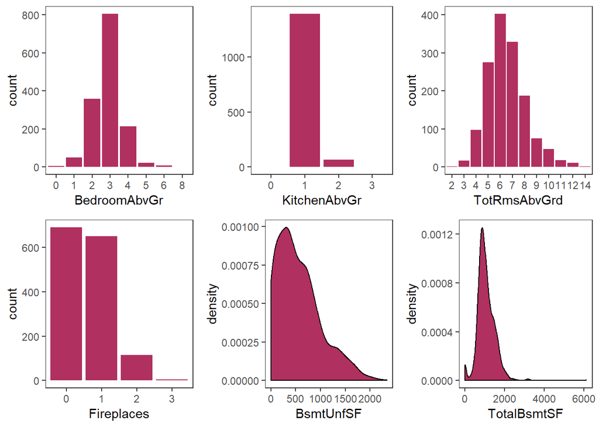

### Implement Linear model

```
##
## Call:
## lm(formula = SalePrice ~ ., data = train.data)
##
## Residuals:
##     Min      1Q  Median      3Q     Max
## -366153  -12084    -443   10817  161550
##
## Coefficients: (2 not defined because of singularities)
##                   Estimate Std. Error t value Pr(>|t|)
## (Intercept)     -2.351e+05  1.739e+06  -0.135 0.892535
## MSSubClass30     1.778e+03  7.354e+03   0.242 0.808991
## MSSubClass40    -4.003e+03  1.872e+04  -0.214 0.830750
## MSSubClass45     1.049e+04  1.252e+04   0.838 0.402541
## MSSubClass50     2.792e+02  6.895e+03   0.040 0.967709
## MSSubClass60    -5.244e+02  8.453e+03  -0.062 0.950548
## MSSubClass70     8.772e+03  1.008e+04   0.870 0.384573
## MSSubClass75    -1.235e+04  1.510e+04  -0.818 0.413904
## MSSubClass80    -4.452e+03  6.938e+03  -0.642 0.521315
## MSSubClass85    -5.304e+03  1.177e+04  -0.451 0.652431
## MSSubClass90    -1.984e+04  1.451e+04  -1.367 0.171926
## MSSubClass120   -9.534e+03  6.071e+03  -1.570 0.116795
## MSSubClass160   -1.859e+04  9.233e+03  -2.013 0.044454 *
## MSSubClass180   -8.562e+03  1.656e+04  -0.517 0.605265
## MSSubClass190    2.542e+03  1.258e+04   0.202 0.839916
## LotFrontage      1.607e+01  6.704e+01   0.240 0.810591
## LotArea          3.993e-01  1.779e-01   2.245 0.025087 *
## OverallQual3    -3.208e+04  3.277e+04  -0.979 0.327845
## OverallQual4    -2.431e+04  2.920e+04  -0.833 0.405368
## OverallQual5    -2.303e+04  2.946e+04  -0.782 0.434499
## OverallQual6    -2.067e+04  2.958e+04  -0.699 0.484803
## OverallQual7    -5.658e+03  2.995e+04  -0.189 0.850194
## OverallQual8     2.212e+04  3.036e+04   0.729 0.466388
## OverallQual9     7.091e+04  3.089e+04   2.295 0.022013 *
## OverallQual10    7.545e+04  3.301e+04   2.286 0.022584 *
## OverallCond3    -5.628e+04  3.306e+04  -1.702 0.089159 .
## OverallCond4    -2.481e+04  3.238e+04  -0.766 0.443788
## OverallCond5    -2.016e+04  3.158e+04  -0.638 0.523545
## OverallCond6    -1.138e+04  3.176e+04  -0.358 0.720240
## OverallCond7    -5.646e+03  3.189e+04  -0.177 0.859512
```

[output cut: 57 more lines]

```
## BsmtFinType1LwQ -4.006e+03  6.201e+03  -0.646 0.518475
## BsmtFinType1Rec  5.127e+02  4.826e+03   0.106 0.915423
## BsmtFinType1Unf  1.168e+03  4.643e+03   0.252 0.801476
## BsmtFinType2BLQ -1.135e+04  1.314e+04  -0.864 0.388089
## BsmtFinType2GLQ -5.203e+03  1.417e+04  -0.367 0.713610
## BsmtFinType2LwQ -1.092e+04  1.273e+04  -0.858 0.391080
## BsmtFinType2Rec -1.056e+04  1.142e+04  -0.925 0.355075
## BsmtFinType2Unf -7.077e+03  1.220e+04  -0.580 0.562138
## ---
## Signif. codes:  0 '***' 0.001 '**' 0.01 '*' 0.05 '.' 0.1 ' ' 1
##
## Residual standard error: 29490 on 684 degrees of freedom
##   (252 observations deleted due to missingness)
## Multiple R-squared:  0.8927, Adjusted R-squared:  0.8783
## F-statistic: 61.87 on 92 and 684 DF,  p-value: < 2.2e-16
```

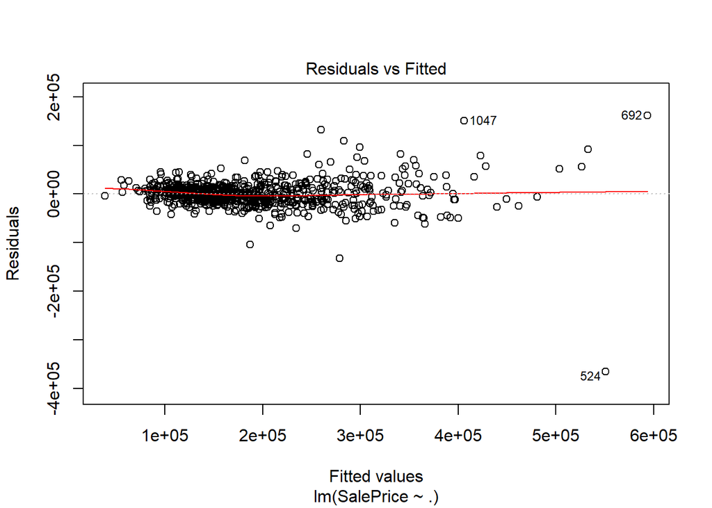

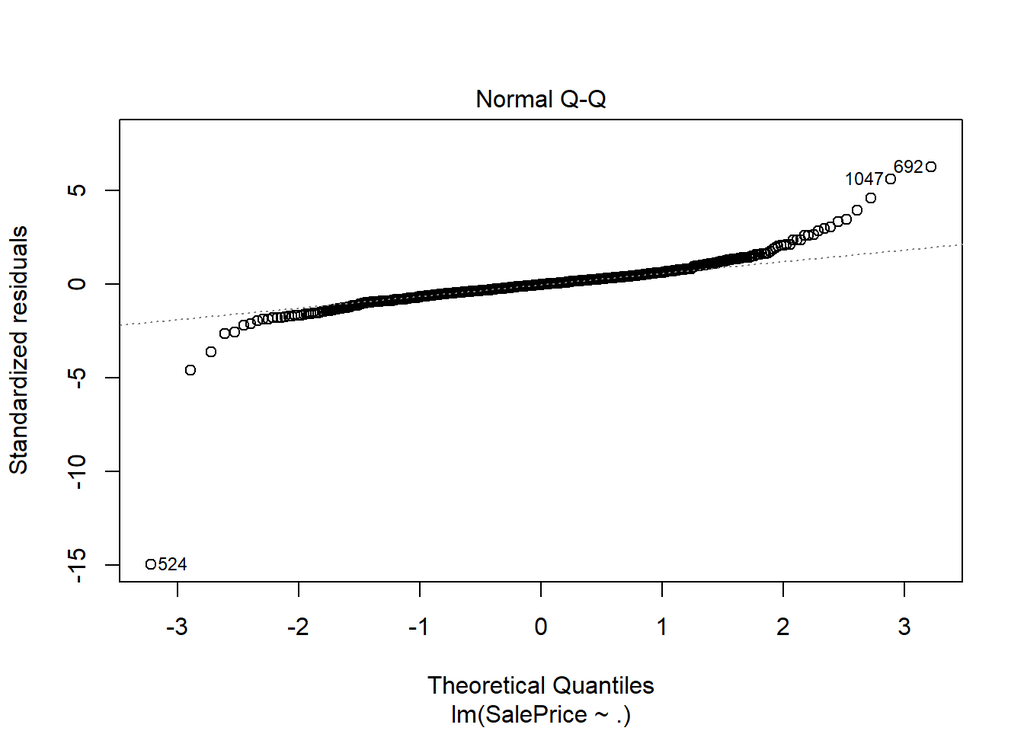

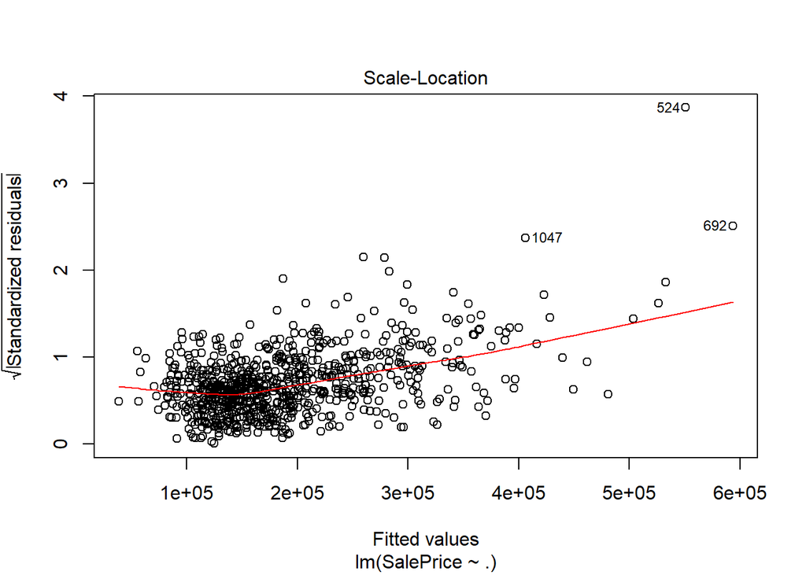

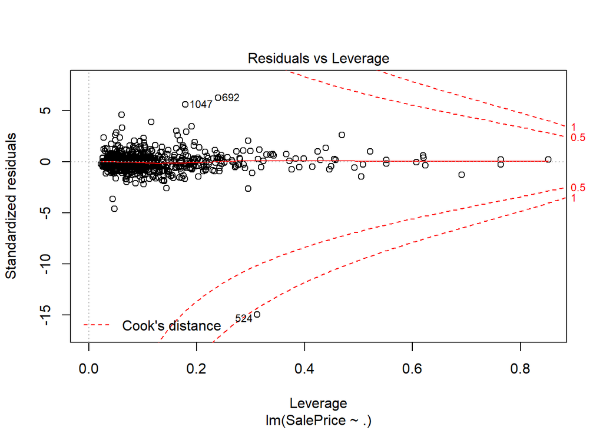